# Visualización en el espacio: histograma, caja y bigotes, y lo que ninguno de los dos ve

Estadística Multidimensional · 26158 · Unidad 2 · Sesión 4 — sábado 22 de agosto de 2026

Jhon Alejandro Varón Robayo · Universidad Distrital Francisco José de Caldas

# 1 De dónde venimos

La sesión pasada terminó con una matriz **X** de $n$ filas por $p$ columnas y con un problema: `airquality` tenía **4,8 % de celdas vacías** y perdía **27,5 % de las filas**. Hoy empezamos a mirar esa matriz, y la pregunta de la sesión es sencilla de enunciar y difícil de responder:

> **¿Cómo se ve una nube de puntos en $p$ dimensiones, si sólo podemos dibujar dos?**

## 1.1 Los datos de hoy

`winequality-red.csv`: 1.599 vinos tintos portugueses, once medidas fisicoquímicas y una calificación de calidad de 0 a 10 dada por catadores.

```r
vino <- read.csv("../../../04_DATASETS/winequality-red.csv")
dim(vino)
```

```
#> [1] 1599   12
```

```r
names(vino)
```

```
#>  [1] "fixed_acidity"        "volatile_acidity"     "citric_acid"
#>  [4] "residual_sugar"       "chlorides"            "free_sulfur_dioxide"
#>  [7] "total_sulfur_dioxide" "density"              "pH"
#> [10] "sulphates"            "alcohol"              "quality"
```

Note que aquí `read.csv()` funcionó **de una**, sin pelear con `sep` ni con `dec`. Es la excepción, no la regla: el archivo del DANE de la sesión pasada se abrió en una sola columna sin dar ningún error. La lección no cambia — **siempre se verifica con `dim()` y `str()` después de importar**—, pero conviene ver también un archivo que sí venía limpio.

```r
str(vino)
```

```
#> 'data.frame':    1599 obs. of  12 variables:
#>  $ fixed_acidity       : num  7.4 7.8 7.8 11.2 7.4 7.4 7.9 7.3 7.8 7.5 ...
#>  $ volatile_acidity    : num  0.7 0.88 0.76 0.28 0.7 0.66 0.6 0.65 0.58 0.5 ...
#>  $ citric_acid         : num  0 0 0.04 0.56 0 0 0.06 0 0.02 0.36 ...
#>  $ residual_sugar      : num  1.9 2.6 2.3 1.9 1.9 1.8 1.6 1.2 2 6.1 ...
#>  $ chlorides           : num  0.076 0.098 0.092 0.075 0.076 0.075 0.069 0.065 0.073 0.071 ...
#>  $ free_sulfur_dioxide : num  11 25 15 17 11 13 15 15 9 17 ...
#>  $ total_sulfur_dioxide: num  34 67 54 60 34 40 59 21 18 102 ...
#>  $ density             : num  0.998 0.997 0.997 0.998 0.998 ...
#>  $ pH                  : num  3.51 3.2 3.26 3.16 3.51 3.51 3.3 3.39 3.36 3.35 ...
#>  $ sulphates           : num  0.56 0.68 0.65 0.58 0.56 0.56 0.46 0.47 0.57 0.8 ...
#>  $ alcohol             : num  9.4 9.8 9.8 9.8 9.4 9.4 9.4 10 9.5 10.5 ...
#>  $ quality             : int  5 5 5 6 5 5 5 7 7 5 ...
```

Once variables numéricas continuas y `quality`, que es un entero de 3 a 8 y que vamos a tratar como **variable categórica**: es la nota del catador, no una magnitud física.

```r
table(vino$quality)
```

```
#>
#>   3   4   5   6   7   8
#>  10  53 681 638 199  18
```

> **Este dataset está vetado para el proyecto** (§7 del enunciado de la propuesta), justamente porque lo vamos a usar en clase. Sirve para aprender; no sirve para que ustedes tengan algo que descubrir.

# 2 El histograma, y la decisión que esconde

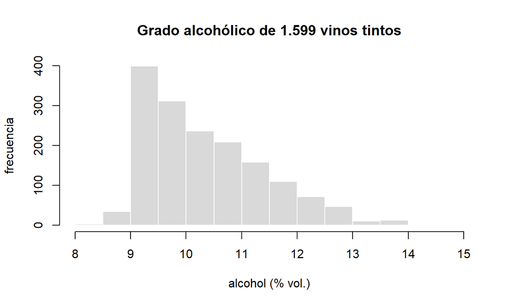

```r
hist(vino$alcohol,
     main = "Grado alcohólico de 1.599 vinos tintos",
     xlab = "alcohol (% vol.)", ylab = "frecuencia",
     col = "grey85", border = "white")
```

La distribución es **asimétrica a la derecha**: muchos vinos entre 9 y 11 grados, y una cola larga de vinos fuertes. Hasta aquí, nada polémico.

## 2.1 El mismo dato, tres histogramas distintos

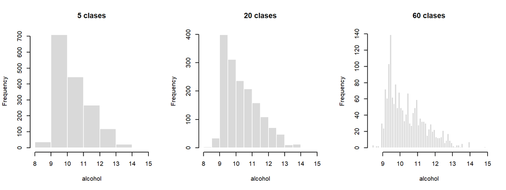

```r
par(mfrow = c(1, 3))
hist(vino$alcohol, breaks = 5,  main = "5 clases",  xlab = "alcohol", col = "grey85", border = "white")
hist(vino$alcohol, breaks = 20, main = "20 clases", xlab = "alcohol", col = "grey85", border = "white")
hist(vino$alcohol, breaks = 60, main = "60 clases", xlab = "alcohol", col = "grey85", border = "white")
```

```r
par(mfrow = c(1, 1))
```

```r
ceiling(log2(nrow(vino))) + 1
```

```
#> [1] 12
```

> **El número de clases es una decisión del analista, no un dato del problema.** En el informe final va declarado: *«histograma con 20 clases»*. Un gráfico sin esa declaración no es reproducible.

# 3 Caja y bigotes: cinco números

```r
fivenum(vino$alcohol)
```

```
#> [1]  8.4  9.5 10.2 11.1 14.9
```

```r
summary(vino$alcohol)
```

```
#>    Min. 1st Qu.  Median    Mean 3rd Qu.    Max.
#>    8.40    9.50   10.20   10.42   11.10   14.90
```

Los cinco números son mínimo, primer cuartil, mediana, tercer cuartil y máximo: **8,4 · 9,5 · 10,2 · 11,1 · 14,9**.

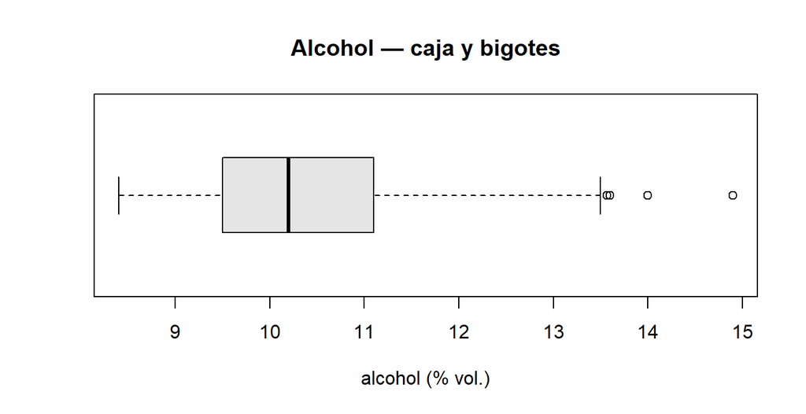

```r
boxplot(vino$alcohol, horizontal = TRUE,
        main = "Alcohol — caja y bigotes",
        xlab = "alcohol (% vol.)", col = "grey90")
```

## 3.1 Qué es cada cosa

| Elemento | Qué es | Aquí vale |
| --- | --- | --- |
| Caja | de $Q_1$ a $Q_3$ | 9,5 a 11,1 |
| Línea de la caja | **mediana**, no la media | 10,2 |
| Ancho de la caja | **rango intercuartílico** $RIC = Q_3 - Q_1$ | 1,6 |
| Bigote superior | hasta el dato más grande que no pase $Q_3 + 1{,}5 \cdot RIC$ | 13,5 |
| Puntos sueltos | candidatos a **atípico** | 13 vinos |

```r
q <- quantile(vino$alcohol, c(0.25, 0.75))
ric <- q[2] - q[1]
c(Q1 = q[[1]], Q3 = q[[2]], RIC = ric[[1]],
  bigote_sup = q[[2]] + 1.5 * ric[[1]])
```

```
#>         Q1         Q3        RIC bigote_sup
#>        9.5       11.1        1.6       13.5
```

```r
sum(vino$alcohol > q[[2]] + 1.5 * ric[[1]])
```

```
#> [1] 13
```

**El bigote no llega al máximo.** Llega hasta el último dato que no supere $Q_3 + 1{,}5 \cdot RIC$. Los 13 vinos por encima de 13,5 grados se dibujan como puntos: son atípicos **en esta variable**. Guarden esa frase, porque en un rato va a resultar insuficiente.

## 3.2 Comparar grupos: el primer gráfico bivariante del curso

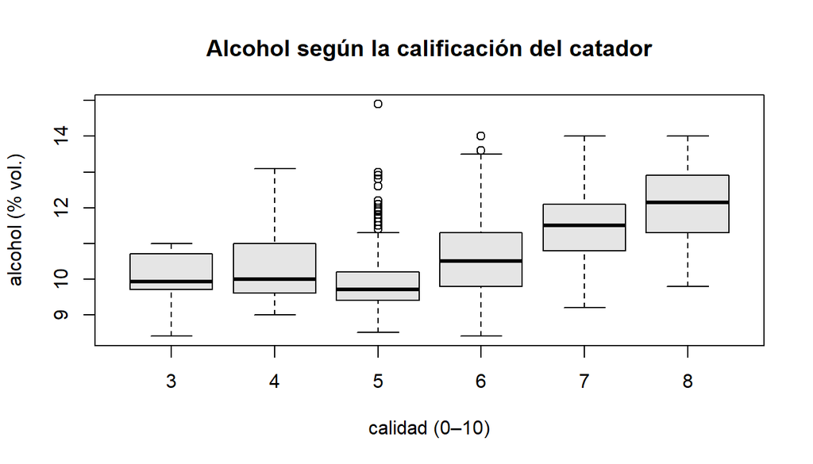

```r
boxplot(alcohol ~ quality, data = vino,
        main = "Alcohol según la calificación del catador",
        xlab = "calidad (0–10)", ylab = "alcohol (% vol.)",
        col = "grey90")
```

Aquí hay **dos variables a la vez**: una numérica y una categórica. Y se ve algo — los vinos mejor calificados tienden a tener más alcohol.

Ojo con lo que acabamos de hacer: *ver* una diferencia no es *demostrarla*. La pregunta «¿esa diferencia es real o es el azar del muestreo?» es un **contraste de hipótesis**, y la respondemos en la unidad 5, cuando las medias que comparemos ya no sean números sino vectores.

# 4 Las once variables juntas

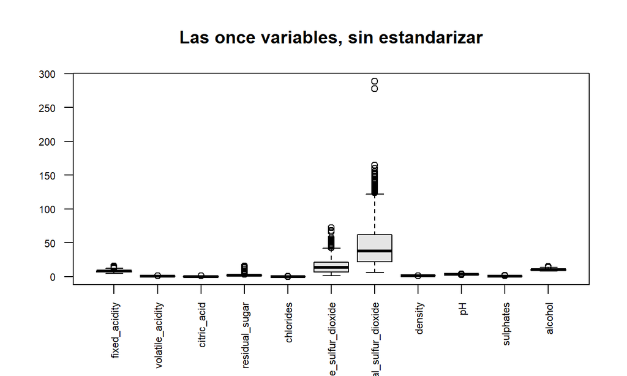

```r
boxplot(vino[, 1:11], las = 2, cex.axis = 0.7,
        main = "Las once variables, sin estandarizar",
        col = "grey90")
```

No se ve **nada**, y la razón es puramente de escala:

```r
round(sapply(vino[, 1:11], sd), 4)
```

```
#>        fixed_acidity     volatile_acidity          citric_acid
#>               1.7411               0.1791               0.1948
#>       residual_sugar            chlorides  free_sulfur_dioxide
#>               1.4099               0.0471              10.4602
#> total_sulfur_dioxide              density                   pH
#>              32.8953               0.0019               0.1544
#>            sulphates              alcohol
#>               0.1695               1.0657
```

`total_sulfur_dioxide` tiene desviación estándar **32,9** y `density` tiene **0,0019**. Son cuatro órdenes de magnitud de diferencia: en el mismo eje, la segunda es una raya.

## 4.1 Estandarizar

$$z_{ij} = \frac{x_{ij} -
\bar{x}_j}{s_j}$$

Cada variable queda con media 0 y desviación 1, y **todas pasan a hablar el mismo idioma**: «cuántas desviaciones estándar me alejo de mi propia media».

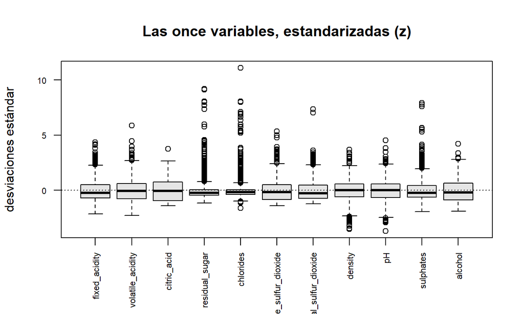

```r
boxplot(scale(vino[, 1:11]), las = 2, cex.axis = 0.7,
        main = "Las once variables, estandarizadas (z)",
        ylab = "desviaciones estándar", col = "grey90")
abline(h = 0, lty = 3)
```

Ahora sí se compara: `chlorides` y `residual_sugar` tienen colas derechas larguísimas, mientras `density` y `pH` son casi simétricas.

> **`scale()` va a volver.** Es la misma decisión que define el PCA de la unidad 6: hacerlo sobre la matriz de covarianzas (sin estandarizar) o sobre la de correlaciones (estandarizando). Con variables en unidades distintas, casi siempre es la segunda.

# 5 El punto que ningún boxplot ve

Aquí está el argumento de la asignatura completa.

## 5.1 Dos variables que se mueven juntas

```r
cor(vino$density, vino$alcohol)
```

```
#> [1] -0.4961798
```

**−0,496.** Los vinos más alcohólicos son **menos densos** —el alcohol pesa menos que el agua—. No es una curiosidad química: es una **restricción** sobre qué combinaciones de valores son posibles en la práctica.

## 5.2 Un vino imposible

Inventamos un vino con densidad **1,0010** y alcohol **13,4**:

```r
raro <- data.frame(density = 1.0010, alcohol = 13.4)

lim_dens <- quantile(vino$density, 0.75) + 1.5 * IQR(vino$density)
lim_alc  <- quantile(vino$alcohol, 0.75) + 1.5 * IQR(vino$alcohol)

c(limite_density = lim_dens[[1]], valor = raro$density,
  marcado_como_atipico = raro$density > lim_dens[[1]])
```

```
#>       limite_density                valor marcado_como_atipico
#>             1.001187             1.001000             0.000000
```

```r
c(limite_alcohol = lim_alc[[1]], valor = raro$alcohol,
  marcado_como_atipico = raro$alcohol > lim_alc[[1]])
```

```
#>       limite_alcohol                valor marcado_como_atipico
#>                 13.5                 13.4                  0.0
```

**Ninguno de los dos boxplots lo marca.** 1,0010 está por debajo del límite 1,0012, y 13,4 por debajo de 13,5. Mirando variable por variable, este vino es perfectamente normal.

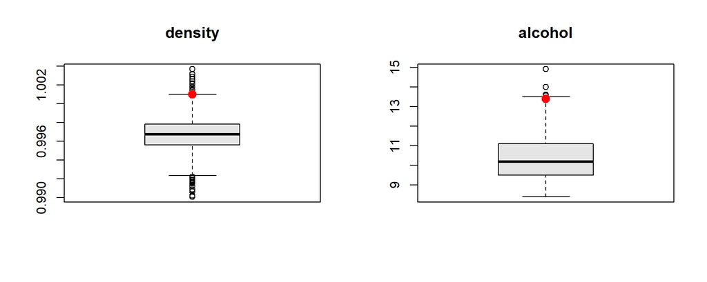

```r
par(mfrow = c(1, 2))
boxplot(vino$density, main = "density", col = "grey90"); points(1, raro$density, col = "red", pch = 19, cex = 1.4)
boxplot(vino$alcohol, main = "alcohol", col = "grey90"); points(1, raro$alcohol, col = "red", pch = 19, cex = 1.4)
```

```r
par(mfrow = c(1, 1))
```

## 5.3 Ahora los dos ejes a la vez

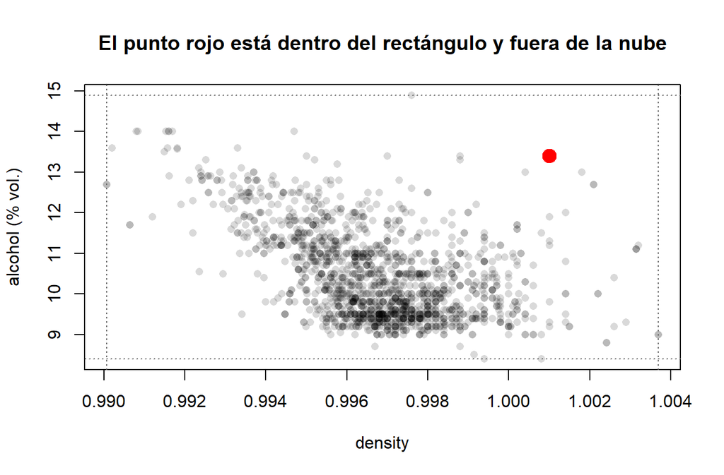

```r
plot(vino$density, vino$alcohol,
     pch = 16, col = rgb(0, 0, 0, 0.15),
     xlab = "density", ylab = "alcohol (% vol.)",
     main = "El punto rojo está dentro del rectángulo y fuera de la nube")
points(raro$density, raro$alcohol, col = "red", pch = 19, cex = 1.8)

abline(v = range(vino$density), lty = 3, col = "grey40")
abline(h = range(vino$alcohol),  lty = 3, col = "grey40")
```

**Está solo.** Dentro del rango de cada variable, y lejísimos de donde vive la nube.

### La idea, en una frase

> El boxplot vigila un **intervalo** por variable, y eso dibuja un **rectángulo**. Los datos correlacionados no llenan el rectángulo: llenan una **elipse** inclinada dentro de él. Todo el espacio entre la elipse y las esquinas del rectángulo son valores que **parecen normales uno por uno y son imposibles en conjunto**.

La distancia que sí detecta ese punto —la que mide en unidades de la elipse y no del rectángulo— se llama **distancia de Mahalanobis**, y es el tema de la unidad 4, el **sábado 3 de octubre**.

## 5.4 Y por qué no basta con mirar todos los pares

Con $p$ variables hay $\binom{p}{2}$ diagramas de dispersión:

```r
p <- 11
choose(p, 2)
```

```
#> [1] 55
```

```r
choose(30, 2)
```

```
#> [1] 435
```

**55** gráficos para este dataset; **435** si tuviéramos 30 variables. Y aun mirándolos todos, hay estructuras que sólo aparecen en tres variables a la vez y en ningún par. Ésa es la razón de existir de esta asignatura: métodos que miran las $p$ dimensiones **de una sola vez**.

# 6 Las cinco ideas de hoy

1. El **número de clases** de un histograma es una decisión, y hay que declararla.
2. El boxplot resume una variable en **cinco números** y marca atípicos con $1{,}5 \cdot RIC$.
3. Para comparar $p$ variables en un solo gráfico hay que **estandarizar**.
4. **Un punto puede ser normal en cada variable por separado y atípico en el conjunto.** El rectángulo no es la elipse.
5. Mirar de a pares **no escala**: 55 gráficos aquí, 435 con 30 variables.

# 7 Para la próxima sesión

- **Lunes 24:** densidad kernel y diagrama de dispersión. Ya con el dataset asignado a cada grupo.
- **Sábado 29:** matriz de dispersión y matriz de correlación — los 55 gráficos, en un solo objeto.